# PLSC 468 Pset 3

# Part 2

**Goal: Setting k = K, estimate the following topic models. For each model, produce a list of the top 10 most frequent works across each of the k topics**

## 2a: Unsupervised LDA model using lda::lda.collapsed.gibs.sampler(.., k)

Here we run the pre-processed string “txts” through the lexacalize fuction to enable use of the lda package. In this model we manually set k, alpha, and eta here for the remainder of lda() models. We define these model parameters as global variables that are then used for all lda models. We use the value of k determined above for the number of topics.

```r
#processing text for lda analysis
vocab = docs[[2]]
result=list()

#preset parameters for lda() models
alpha = 1.0
eta = 0.1
params = sample(c(-1, 1), k, replace=TRUE)

#running the model!
result_2a=lda.collapsed.gibbs.sampler(docs[[1]],
    k,
    vocab,
    100,
    alpha = alpha,
    eta = eta,
    compute.log.likelihood=TRUE
)
```

Top Words

```r
lda_results <- top.topic.words(result_2a$topics,10)
colnames(lda_results) <- c("Topic 1", "Topic 2", "Topic 3", "Topic 4", "Topic 5", "Topic 6", "Topic 7",
                          "Topic 8", "Topic 9", "Topic 10", "Topic 11")
rownames(lda_results) <- c("#1", "#2", "#3", "#4", "#5", "#6" , "#7", "#8", "9", "#10")

as.data.frame(lda_results)
```

```
##     Topic 1 Topic 2   Topic 3  Topic 4  Topic 5 Topic 6 Topic 7  Topic 8
## #1     bush         healthcar       im    liber     tax           energi
## #2      job   secur   veteran    steve       im              im      oil
## #3           street  children   famili     vote    rais     tom       im
## #4    class    wall      help congress    illeg    vote   senat      gas
## #5    middl  social     fight     valu   attack   spend    serv    price
## #6      tax economi                hes    harri increas   state     need
## #7     vote  dollar       kid    chris   immigr     pay     law  america
## #8  support      us      keep     work      say  higher    year      new
## 9     georg   crisi      care     make   record  famili      us   becaus
## #10   break    vote     insur   becaus democrat     jim  alaska american
##     Topic 9   Topic 10 Topic 11
## #1     john         im
## #2       im       work      big
## #3               peopl interest
## #4      can washington  compani
## #5     will        get  special
## #6   leader        job       im
## #7     paul         go   dollar
## #8     mari     becaus     year
## 9      onli       know campaign
## #10      al      chang mcconnel
```

## 2b: Supervised LDA model to predict *party* using lda::slda.em(…, party, k)

Next, we introduce party into our model.

```r
# annotation to predict
y=ads$party

result_2b=slda.em(documents=docs[[1]],
        K=k,
        vocab=vocab,
        num.e.iterations=10,
        num.m.iterations=4,
        alpha=alpha, eta=eta,
        annotations=y,
        params,
        variance=0.25,
        lambda=1.0,
        logistic=FALSE,
        method="sLDA"
)
```

Top Words

```r
slda_party_results <- top.topic.words(result_2b$topics,10)

colnames(slda_party_results) <- c("Topic 1", "Topic 2", "Topic 3", "Topic 4", "Topic 5", "Topic 6", "Topic 7",
                          "Topic 8", "Topic 9", "Topic 10", "Topic 11")
rownames(slda_party_results) <- c("#1", "#2", "#3", "#4", "#5", "#6" , "#7", "#8", "9", "#10")
as.data.frame(slda_party_results)
```

```
##     Topic 1  Topic 2  Topic 3 Topic 4    Topic 5    Topic 6 Topic 7 Topic 8
## #1           veteran   energi                 im         im     tax
## #2      now       im       im    john washington       work    rais    bush
## #3     vote     bill      gas  dollar      chris      chang  famili     big
## #4      law     john    price      im      peopl washington            vote
## #5    money       us      oil    vote        hes        job   steve    time
## #6   alaska      new     need  street   mcconnel       need     job     tax
## #7     said     iraq  america   money      think       will increas   break
## #8  respons      hes american million       dont        get  higher   class
## 9      just congress      new    wall         go        can    busi   middl
## #10     one               job   illeg     becaus     becaus economi     oil
##       Topic 9    Topic 10 Topic 11
## #1                   vote       im
## #2  healthcar
## #3      secur        mark     work
## #4     social         tom    senat
## #5   children       liber     valu
## #6        kid          im     know
## #7      insur congressman   leader
## #8       vote        udal    smith
## 9         jim     conserv     make
## #10      paul       obama   famili
```

## 2c: Supervised LDA model to predict *tone* using lda::slda.em(…, tone, k)

```r
# annotation to predict
y=ads$tone

result_2c=slda.em(documents=docs[[1]],
        K=k,
        vocab=vocab,
        num.e.iterations=10,
        num.m.iterations=4,
        alpha=alpha, eta=eta,
        annotations=y,
        params,
        variance=0.25,
        lambda=1.0,
        logistic=FALSE,
        method="sLDA"
)
```

Top Ten Words

```r
slda_tone_results <- top.topic.words(result_2c$topics,10)

colnames(slda_tone_results) <- c("Topic 1", "Topic 2", "Topic 3", "Topic 4", "Topic 5", "Topic 6", "Topic 7",
                          "Topic 8", "Topic 9", "Topic 10", "Topic 11")
rownames(slda_tone_results) <- c("#1", "#2", "#3", "#4", "#5", "#6" , "#7", "#8", "9", "#10")

as.data.frame(slda_tone_results)
```

```
##     Topic 1 Topic 2 Topic 3 Topic 4    Topic 5  Topic 6   Topic 7 Topic 8
## #1  veteran     tax  energi      im         im          healthcar
## #2       im              im         washington interest     fight    vote
## #3             rais     oil      go      chang      jim  children     tax
## #4     iraq     job   price     hes       need   attack    famili     big
## #5     serv  famili     gas   peopl     becaus  special       kid billion
## #6    troop increas     new     one       work campaign      make     oil
## #7      war  higher america    year        can   record      help   liber
## #8     fund    vote    need   senat        job       ad      keep  dollar
## 9      bill     pay     job  alaska        get    money     insur   break
## #10    help     cut   drill   state      peopl    chris     class compani
##     Topic 9 Topic 10    Topic 11
## #1                im          im
## #2     bush     work        john
## #3   street    senat        valu
## #4     wall     will     conserv
## #5    steve      get       illeg
## #6    secur      job  republican
## #7   social       us congressman
## #8     vote                 vote
## 9   support     time
## #10  econom      hes    congress
```

## 2d: Structural topic model using stm::stm(…, prevalence = ~ party + tone, k)

In work done in part 1, we cleaned our data using textProcessor() and prepDocuments() and determined the best value of k, so we are ready to run an sTM model.

```r
result_2d = stm(documents=outs_stm$documents,vocab=outs_stm$vocab,K=k,
    prevalence=~party+tone,data=outs_stm$meta)
```

[output not shown]

[output cut: 65 more lines]

[output not shown]

If we want to get a sense of only the 3 top words associated with each topic and also the prevalence of topics in order to sense-check our groups, we can use the plot function.

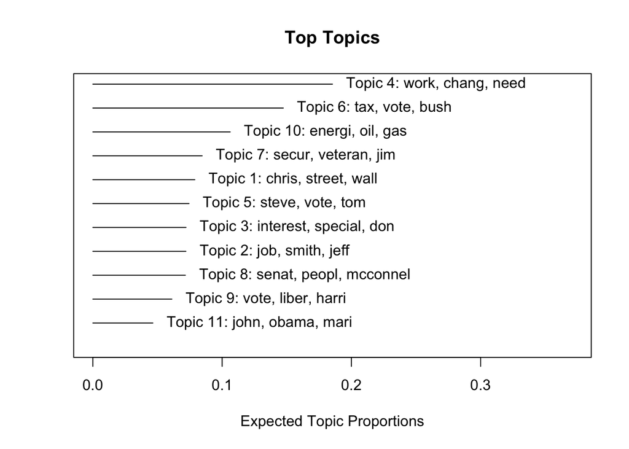

```r
# view 3 top words associated with each topic
plot(result_2d)
```

For this assignment, we are interested in collecting the top 10 words in each category.

```r
stm_results_2d <- t(labelTopics(model=result_2d, topics = NULL, n = 10, frexweight = 0.5)[1]$prob)

colnames(stm_results_2d) <- c("Topic 1", "Topic 2", "Topic 3", "Topic 4", "Topic 5", "Topic 6", "Topic 7",
                          "Topic 8", "Topic 9", "Topic 10", "Topic 11")
rownames(stm_results_2d) <- c("#1", "#2", "#3", "#4", "#5", "#6" , "#7", "#8", "9", "#10")
as.data.frame(stm_results_2d)
```

```
##      Topic 1    Topic 2     Topic 3    Topic 4 Topic 5 Topic 6 Topic 7  Topic 8
## #1     chris        job    interest       work   steve     tax   secur    senat
## #2    street      smith     special      chang    vote    vote veteran    peopl
## #3      wall       jeff         don       need     tom    bush     jim mcconnel
## #4       kay     gordon      alaska     famili   illeg     rai  social      hes
## #5    dollar    merkley        paul washington     new  famili    vote  coleman
## #6     hagan    economi    congress     becaus  immigr     cut    iraq     norm
## #7      dole      creat congressman        job  border   middl    bill  franken
## #8  campaign      roger         one       make conserv   class   troop lunsford
## 9   congress washington      steven        can  mexico    time support kentucki
## #10  million      spend        take   congress   secur   break  street    mitch
##      Topic 9  Topic 10   Topic 11
## #1      vote    energi       john
## #2     liber       oil      obama
## #3     harri       gas       mari
## #4    parker     price   landrieu
## #5  congress healthcar       vote
## #6      wayn      mark washington
## #7  democrat       kid     sununu
## #8      want   america    shadegg
## 9       love     drill    kennedi
## #10  conserv  children      fleme
```

## 2e: Structural topic model using stm::stm(…, prevalence = ~ party + tone + office + policy + as.factor(state), k)

We repeat the same analysis as in 2d but use more variables for the modeling.

```r
result_2e = stm(documents=outs_stm$documents,vocab=outs_stm$vocab,K=k,
    prevalence=~party+tone+office+policy+as.factor(state),data=outs_stm$meta)
```

[output not shown]

[output cut: 212 more lines]

[output not shown]

If we want to get a sense of only the 3 top words associated with each topic and also the prevalence of topics in order to sense-check our groups, we can use the plot function.

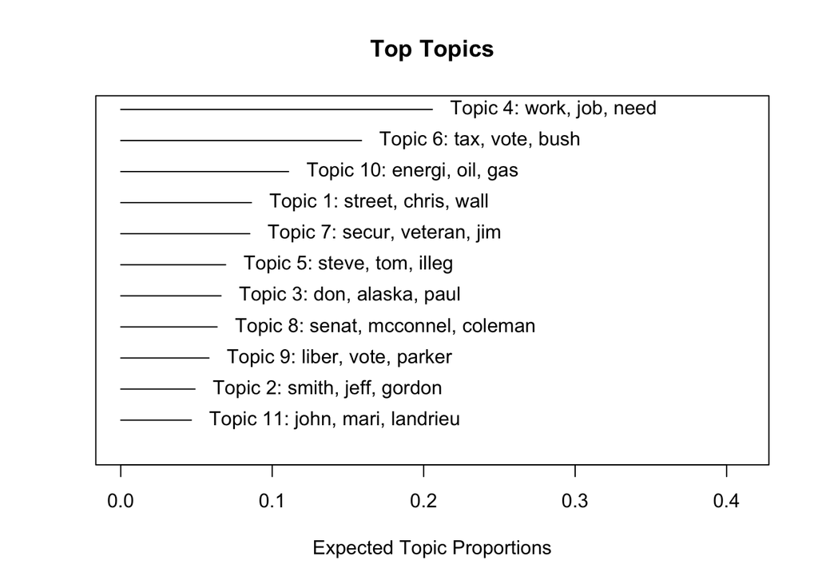

```r
# view 3 top words associated with each topic
plot(result_2e)
```

For this assignment, we are interested in collecting the top 10 words in each category.

```r
stm_results_2e <- t(labelTopics(model=result_2e, topics = NULL, n = 10, frexweight = 0.5)[1]$prob)


colnames(stm_results_2e) <- c("Topic 1", "Topic 2", "Topic 3", "Topic 4", "Topic 5", "Topic 6", "Topic 7",
                          "Topic 8", "Topic 9", "Topic 10", "Topic 11")
rownames(stm_results_2e) <- c("#1", "#2", "#3", "#4", "#5", "#6" , "#7", "#8", "9", "#10")
as.data.frame(stm_results_2e)
```

```
##        Topic 1     Topic 2     Topic 3    Topic 4     Topic 5 Topic 6 Topic 7
## #1      street       smith         don       work       steve     tax   secur
## #2       chris        jeff      alaska        job         tom    vote veteran
## #3        wall      gordon        paul       need       illeg    bush     jim
## #4    congress     merkley congressman washington        vote     rai  social
## #5  washington       roger      steven      chang         new     job    vote
## #6      dollar         job    congress     famili      immigr  famili    iraq
## #7         kay      wicker        will     becaus      border     cut    bill
## #8       hagan     musgrov     special      fight      mexico    time   troop
## 9         dole mississippi    interest        can congressman   class support
## #10      money      oregon    carmouch      peopl       secur   middl   retir
##      Topic 8  Topic 9  Topic 10   Topic 11
## #1     senat    liber    energi       john
## #2  mcconnel     vote       oil       mari
## #3   coleman   parker       gas   landrieu
## #4      norm    harri     price    shaheen
## #5   franken     wayn healthcar      obama
## #6       hes congress      mark washington
## #7  lunsford  conserv     drill       vote
## #8  kentucki     love       kid     sununu
## 9      mitch    union   america    shadegg
## #10   collin     andi     fight        new
```